# GM12878: parameter choices on real assemblies

This notebook supports the Results section “Parameter choices on real assemblies” (`../manuscript/sections/results_gm12878_parameters.tex`, `sec:parameters`) and Fig. 7 (`fig:parameters`, caption in `figures_main.tex`). It draws Fig. 7 (`figures/fig7_parameters.{pdf,png}`) and computes the numbers the section quotes. Provenance: E13 (start-parameter grid), E04 (minimum length), E20 and E22 (q-value test, development runs), E06 (homology series; release rerun with PyTD a5b24c3) and E25 (release runs).

**Which runs.** The release runs (E25: PyTD 3a793ff; q-value test at q 0.05, 50-codon minimum, start refinement alpha 0.4, Kozak 17 per bit) are used where an equivalent exists or could be derived:

- Fig. 7b (post-hoc minimum length) and the minimum-length paragraph: release ab initio predictions, re-evaluated with `--min-aa` (`pipeline/derive/08_minaa_sweep_final_v7.sh`).
- Fig. 7b markers: the three q settings of the release (`--precise`, default, `--sensitive`). These replace the earlier markers (pre-defined LongOrfs minimum runs from development code), as the caption’s `\todo` asks.
- The q-value paragraph: release protein matches and a release version of the dropped-ORF support table (`pipeline/derive/08_rule_support_v7.py`).
- The homology series (Fig. 7c, d) and the transposable-element paragraph: release rerun with PyTD a5b24c3 (homology-assisted start refinement on; `pipeline/derive/08_homology_series_v7h.sh`, E06 “Release rerun”). The development series (48c870c) is tabulated for comparison.

No release equivalent exists for:

- the start-parameter grid (Fig. 7a; development code 48c870c, E13). Fig. 7a adds the release default as one extra point per assembly;
- the comparison of pre-defined LongOrfs minima (`-m 100`, `-m 50` without a test; E04).

These use the data of the earlier figure.

```r
ASM <- c("lraa", "stringtie", "trinity")
SHORT <- c(lraa = "LRAA", stringtie = "StringTie", trinity = "Trinity")
asm_factor <- function(x) factor(x, levels = ASM, labels = ASM_LABEL[ASM])

# key/value eval summaries (eval_genome_cds.py)
kv <- function(...) {
  x <- readr::read_tsv(data_path(...), col_names = c("key", "value"), show_col_types = FALSE,
                       col_types = "cc")
  v <- suppressWarnings(as.numeric(x$value)); names(v) <- x$key; v
}
rel_eval <- function(asm, setting = "default") {
  suf <- if (setting == "default") "" else paste0("_", setting)
  kv("benchmark", "final_v7", sprintf("eval.%s_final_v7_abinitio%s.summary.tsv", asm, suf))
}

grid <- read_tab("start_param_sensitivity", "gm12878.tsv")
start_share <- read_tab("gm12878", "final_v7", "08_start_share.tsv") %>%
  mutate(share = complete_gencode_exact / complete_gencode_compatible)
sweep_v7 <- read_tab("gm12878", "final_v7", "08_minaa_sweep_v7.tsv")
sweep_dev <- readr::read_tsv(data_path("gm12878", "gm12878_minaa_sweep.tsv"), show_col_types = FALSE,
  col_names = c("assembly", "min_aa", "distinct_predicted_cds", "MANE_sens_exact",
                "MANE_sens_exact_given_assembled", "GENCODE_complete_sens_compatible",
                "pred_all_GENCODE_exact_frac", "pred_all_GENCODE_compatible_frac",
                "pred_all_no_GENCODE_CDS_overlap_frac", "pred_complete_GENCODE_exact_frac"))
by_len <- read_tab("gm12878", "final_v7", "08_no_overlap_by_length.tsv") %>%
  mutate(frac = no_gencode_cds_overlap / n)
pm_v7 <- read_tab("benchmark", "final_v7", "gm12878_v7_protein_matches.tsv") %>%
  separate(label, c("assembly", "setting"), sep = "\\.v7_")
pm_dev <- read_tab("benchmark", "qmodes", "gm12878_qmodes_protein_matches.tsv") %>%
  separate(label, c("assembly", "setting"), sep = "\\.", extra = "merge")
cat_v7 <- read_tab("benchmark", "final_v7", "gm12878_v7_riboseq_orf_catalog_matches.tsv")
sup_v7 <- read_tab("gm12878", "final_v7", "08_rule_support_v7.tsv")
sup_dev <- read_tab("benchmark", "rules", "gm12878_rule_support.tsv")
hom <- read_tab("gm12878", "gm12878_homology_series_v7h.tsv")
hom_dev <- read_tab("gm12878", "gm12878_homology_series.tsv")
ret_txt <- readLines(data_path("gm12878", "gm12878_homology_primate_retention_v7h.txt"))
ret_txt_dev <- readLines(data_path("gm12878", "gm12878_homology_primate_retention.txt"))
te_screen <- read_tab("gm12878", "gm12878_te_screen_v7h.tsv")
```

## Start refinement

Source: `data/start_param_sensitivity/gm12878.tsv` (E13; development code 48c870c, identical to the earlier `final_abinitio` runs at alpha 0.4, w 25 per nat). The grid weight is per nat; 25 per nat is 17.3 per bit, and the shipped 17 per bit differs by rounding only (E13 addendum). The grid was run on LRAA and StringTie only. Rows: no refinement (`norefine`), the default (`a0.4_w25`), the default without the Kozak term (`a0.4_w0`) and alpha 1.0 (`a1.0_w25`).

```r
g <- function(a, cfg, col) grid[[col]][grid$assembly == a & grid$config == cfg]
start_tab <- grid %>% filter(config %in% c("norefine", "a0.4_w0", "a0.4_w25", "a1.0_w25")) %>%
  transmute(assembly, config, `MANE exact given assembled` = MANE_sens_exact_given_assembled,
            `complete, GENCODE exact` = pred_complete_gencode_exact,
            `complete, compatible not exact` = pred_complete_compatible_not_exact,
            `5'-partial` = distinct_predicted_5prime_partial,
            `exact-start share` = pred_complete_start_precision)
kable(start_tab)
```

| assembly | config | MANE exact given assembled | complete, GENCODE exact | complete, compatible not exact | 5’-partial | exact-start share |
| --- | --- | --- | --- | --- | --- | --- |
| lraa | a0.4_w0 | 0.9063 | 11620 | 2337 | 3064 | 0.8326 |
| lraa | a0.4_w25 | 0.9345 | 12018 | 2231 | 2631 | 0.8434 |
| lraa | a1.0_w25 | 0.9547 | 12381 | 2817 | 1149 | 0.8146 |
| lraa | norefine | 0.5906 | 7562 | 1697 | 10693 | 0.8167 |
| stringtie | a0.4_w0 | 0.8957 | 13392 | 3847 | 3429 | 0.7768 |
| stringtie | a0.4_w25 | 0.9270 | 13805 | 3796 | 3030 | 0.7843 |
| stringtie | a1.0_w25 | 0.9492 | 14178 | 4239 | 1547 | 0.7698 |
| stringtie | norefine | 0.6103 | 9309 | 3396 | 10544 | 0.7327 |

- Exact recovery of fully assembled MANE CDSs, no refinement to default: StringTie 61.0% to 92.7%, LRAA 59.1% to 93.5%.
- Exact complete calls: 9,309 to 13,805 and 7,562 to 12,018. 5’-partial calls: 10,544 to 3,030 and 10,693 to 2,631.
- Exact-start share of GENCODE-compatible complete calls: 73.3% to 78.4% and 81.7% to 84.3%.
- Wrong-start complete calls (compatible, not exact): 3,396 to 3,796 and 1,697 to 2,231.
- Kozak term (w 25 vs 0 at alpha 0.4): 3.1 and 2.8 points of MANE exact recovery; 0.7 and 1.1 points of exact-start share.
- alpha 0.4 to 1.0: MANE exact given assembled StringTie 92.7% to 94.9%, LRAA 93.5% to 95.5%; wrong-start complete calls 4,239 and 2,817; exact-start share 77.0% and 81.5%.

**Release runs** (E25; q-value test, w 17 per bit). The exact-start share is computed in the same way from the release `pred_status` tables (`08_start_share.tsv`; the earlier `final_abinitio` rows reproduce the grid’s default cell exactly):

```r
rel_start <- start_share %>% filter(run == "final_v7_abinitio") %>%
  mutate(mane = sapply(assembly, function(a) rel_eval(a)[["MANE_sens_exact_given_assembled"]]))
stopifnot(with(start_share %>% filter(run == "final_abinitio", assembly != "trinity"),
               all(abs(share - c(g("lraa", "a0.4_w25", "pred_complete_start_precision"),
                                 g("stringtie", "a0.4_w25", "pred_complete_start_precision"))) < 1e-4)))
kable(start_share %>% mutate(share = round(share, 4)))
```

| assembly | run | n_complete | complete_gencode_exact | complete_gencode_compatible | share |
| --- | --- | --- | --- | --- | --- |
| lraa | final_abinitio | 18807 | 12018 | 14249 | 0.8434 |
| lraa | final_v7_abinitio | 17806 | 11828 | 13941 | 0.8484 |
| lraa | final_v7_abinitio_precise | 17123 | 11467 | 13486 | 0.8503 |
| lraa | final_v7_abinitio_sensitive | 18388 | 12038 | 14230 | 0.8460 |
| stringtie | final_abinitio | 27034 | 13805 | 17601 | 0.7843 |
| stringtie | final_v7_abinitio | 24077 | 13395 | 16951 | 0.7902 |
| stringtie | final_v7_abinitio_precise | 23060 | 13067 | 16475 | 0.7931 |
| stringtie | final_v7_abinitio_sensitive | 25711 | 13757 | 17529 | 0.7848 |
| trinity | final_abinitio | 52123 | 13826 | 23816 | 0.5805 |
| trinity | final_v7_abinitio | 44494 | 13380 | 22793 | 0.5870 |

Release default: MANE exact given assembled LRAA 92.9%, StringTie 91.5%, Trinity 89.3%; exact-start share 84.8%, 79.0%, 58.7%. The q-value test removes some complete calls, which raises the share slightly and lowers MANE exact recovery (E25). The text’s start-refinement numbers are from the grid and stay valid as a description of the refinement step; the default point in Fig. 7a differs from the release by the ORF acceptance rule.

E13, E09, E25

## Minimum length and the q-value cutoff

### A 50-codon minimum without a test (development runs)

Runs with a pre-defined LongOrfs minimum and no short-ORF test exist only from development code (E04: `m50`, and `kozak_add` = `-m 100`; `data/gm12878/eval_summaries/`). There is no release equivalent.

```r
dev_sum <- function(a, cfg) kv("gm12878", "eval_summaries", sprintf("%s_%s.summary.tsv", a, cfg))
m50_tab <- expand_grid(assembly = c("lraa", "stringtie"),
                       config = c("kozak_add", "m50", "m50_sc200")) %>%
  rowwise() %>%
  mutate(run = c(kozak_add = "-m 100", m50 = "-m 50, no test",
                 m50_sc200 = "-m 50 + fixed short-ORF test")[config],
         distinct_cds = dev_sum(assembly, config)[["distinct_predicted_cds"]],
         MANE_exact_given_assembled = dev_sum(assembly, config)[["MANE_sens_exact_given_assembled"]],
         no_GENCODE_overlap = dev_sum(assembly, config)[["pred_all_no_GENCODE_CDS_overlap_frac"]]) %>%
  ungroup()
kable(m50_tab)
```

| assembly | config | run | distinct_cds | MANE_exact_given_assembled | no_GENCODE_overlap |
| --- | --- | --- | --- | --- | --- |
| lraa | kozak_add | -m 100 | 23546 | 0.9276 | 0.0355 |
| lraa | m50 | -m 50, no test | 26544 | 0.9447 | 0.1071 |
| lraa | m50_sc200 | -m 50 + fixed short-ORF test | 23922 | 0.9345 | 0.0370 |
| stringtie | kozak_add | -m 100 | 32672 | 0.9195 | 0.1181 |
| stringtie | m50 | -m 50, no test | 49601 | 0.9321 | 0.3471 |
| stringtie | m50_sc200 | -m 50 + fixed short-ORF test | 34404 | 0.9269 | 0.1200 |

```r
nov <- function(a, cfg) m50_tab$no_GENCODE_overlap[m50_tab$assembly == a & m50_tab$config == cfg]
```

No GENCODE CDS overlap, `-m 100` to `-m 50` without a test: LRAA 3.5% to 10.7%, StringTie 11.8% to 34.7%. For comparison, the release default gives 1.5% (LRAA), 5.5% (StringTie) and 4.2% (Trinity) (E25).

E04, E25

### Matching and non-matching proteins by q setting

Predicted proteins identical to, or sharing an exact 30-residue window with, a GENCODE v50 protein are “matching”; the rest are “non-matching” (`score_protein_matches.py`). Release runs: `data/benchmark/final_v7/gm12878_v7_protein_matches.tsv` (E25). The development runs quoted in the current text (E22) and the fixed short-ORF test (`cliff_c200`) are in `data/benchmark/qmodes/gm12878_qmodes_protein_matches.tsv`.

```r
SETTING <- c(precise = "q 0.01 (--precise)", default = "q 0.05 (default)",
             sensitive = "q 0.2 (--sensitive)")
dev_map <- c(precise = "decoy_q0.01_longgc", default = "decoy_q0.05_longgc",
             sensitive = "decoy_q0.2_longgc")
q_tab <- pm_v7 %>% select(assembly, setting, matching = true_positives, nonmatching) %>%
  left_join(pm_dev %>% filter(setting %in% dev_map) %>%
              mutate(setting = names(dev_map)[match(setting, dev_map)]) %>%
              select(assembly, setting, dev_matching = true_positives, dev_nonmatching = nonmatching),
            by = c("assembly", "setting")) %>%
  mutate(no_GENCODE_overlap = mapply(function(a, s) rel_eval(a, s)[["pred_all_no_GENCODE_CDS_overlap_frac"]],
                                     assembly, setting),
         MANE_exact_given_assembled = mapply(function(a, s) rel_eval(a, s)[["MANE_sens_exact_given_assembled"]],
                                             assembly, setting),
         catalog_riboseq_orfs = cat_v7$stop_match[match(
           paste0(assembly, "_final_v7_abinitio", ifelse(setting == "default", "", paste0("_", setting))),
           cat_v7$run)])
cliff <- pm_dev %>% filter(setting == "cliff_c200") %>% select(assembly, matching = true_positives, nonmatching)
kable(q_tab %>% mutate(setting = SETTING[setting]))
```

| assembly | setting | matching | nonmatching | dev_matching | dev_nonmatching | no_GENCODE_overlap | MANE_exact_given_assembled | catalog_riboseq_orfs |
| --- | --- | --- | --- | --- | --- | --- | --- | --- |
| lraa | q 0.05 (default) | 32751 | 277 | 32763 | 278 | 0.0150 | 0.9291 | 101 |
| lraa | q 0.01 (–precise) | 31672 | 189 | 32011 | 193 | 0.0116 | 0.9115 | 79 |
| lraa | q 0.2 (–sensitive) | 33443 | 560 | 33508 | 579 | 0.0233 | 0.9385 | 144 |
| stringtie | q 0.05 (default) | 35294 | 1185 | 35391 | 1195 | 0.0547 | 0.9149 | 95 |
| stringtie | q 0.01 (–precise) | 33647 | 698 | 33869 | 749 | 0.0411 | 0.9018 | 81 |
| stringtie | q 0.2 (–sensitive) | 36903 | 2879 | 36903 | 2832 | 0.0960 | 0.9266 | 165 |
| trinity | q 0.05 (default) | 78181 | 2616 | NA | NA | 0.0425 | 0.8933 | 186 |

```r
kable(cliff, caption = "Fixed short-ORF test (development run cliff_c200)")
```

Fixed short-ORF test (development run cliff_c200)

| assembly | matching | nonmatching |
| --- | --- | --- |
| lraa | 33587 | 1005 |
| stringtie | 36547 | 4119 |

```r
q <- function(a, s, col) q_tab[[col]][q_tab$assembly == a & q_tab$setting == s]
cl <- function(a, col) cliff[[col]][cliff$assembly == a]
fold <- sapply(c("lraa", "stringtie"), function(a) cl(a, "nonmatching") / q(a, "default", "nonmatching"))
loss <- sapply(c("lraa", "stringtie"), function(a) 1 - q(a, "default", "matching") / cl(a, "matching"))
fold_dev <- sapply(c("lraa", "stringtie"), function(a) cl(a, "nonmatching") / q(a, "default", "dev_nonmatching"))
loss_dev <- sapply(c("lraa", "stringtie"), function(a) 1 - q(a, "default", "dev_matching") / cl(a, "matching"))
```

Release runs, matching / non-matching (LRAA; StringTie):

- default q 0.05: 32,751 / 277; 35,294 / 1,185. Trinity: 78,181 / 2,616.
- fixed short-ORF test (development): 33,587 / 1,005; 36,547 / 4,119.
- q 0.01: 31,672 / 189; 33,647 / 698.
- q 0.2: 33,443 / 560; 36,903 / 2,879.

At the default, non-matching proteins fell 3.6-fold (LRAA) and 3.5-fold (StringTie), for a loss of 2.5% and 3.4% of matching ones (development runs: 3.6 and 3.4-fold, 2.5% and 3.2%). The no-GENCODE-overlap share of release predictions is 1.2% / 1.5% / 2.3% (LRAA; q 0.01 / 0.05 / 0.2) and 4.1% / 5.5% / 9.6% (StringTie). Catalogued Ribo-seq ORFs matched by stop codon fall from 178 / 217 / 455 with the fixed short-ORF test (E04, E25) to 101 / 95 / 186 at the default.

E22, E20, E25

### Support of the ORFs that the q-value test removed

The text quotes the release version. An earlier draft quoted `gm12878_rule_support.tsv` (E20/E22; development run `decoy_q0.05`, without long-ORF retention, against the development fixed short-ORF run `cliff_c200`), shown below for comparison. The release version, `data/gm12878/final_v7/08_rule_support_v7.tsv` (`pipeline/derive/08_rule_support_v7.py`), compares the release runs with the earlier `final_abinitio` runs (fixed short-ORF test; their Ribo-seq and MS tables from E01/E02). An ORF is identified by transcript, strand and stop codon. “dropped” are `final_abinitio` ORFs with no release prediction with that stop; “all” are the release predictions, scored with the release Ribo-seq and MS tables (E25). Ribo-seq rates are over ORFs with at least ten P-sites; MS rates are over all ORFs (gene models).

```r
kable(sup_v7, caption = "Release (08_rule_support_v7.tsv)")
```

Release (08_rule_support_v7.tsv)

| asm | setting | set | n | ribo_n | ribo_sup | ribo_rate | ms_sup | ms_rate |
| --- | --- | --- | --- | --- | --- | --- | --- | --- |
| lraa | baseline_fixed_short_orf_test | all | 34592 | 20214 | 13179 | 0.6520 | 21780 | 0.6296 |
| lraa | default | all | 33028 | 19862 | 13057 | 0.6574 | 21298 | 0.6448 |
| lraa | default | kept | 32853 | 19750 | 12997 | 0.6581 | 21169 | 0.6444 |
| lraa | default | dropped | 1739 | 464 | 182 | 0.3922 | 611 | 0.3514 |
| lraa | default | added | 175 | 87 | 42 | 0.4828 | 103 | 0.5886 |
| lraa | precise | all | 31861 | 19349 | 12840 | 0.6636 | 20714 | 0.6501 |
| lraa | precise | kept | 31706 | 19225 | 12772 | 0.6643 | 20575 | 0.6489 |
| lraa | precise | dropped | 2886 | 989 | 407 | 0.4115 | 1205 | 0.4175 |
| lraa | precise | added | 155 | 85 | 43 | 0.5059 | 97 | 0.6258 |
| lraa | sensitive | all | 34003 | 20188 | 13180 | 0.6529 | 21721 | 0.6388 |
| lraa | sensitive | kept | 33676 | 20041 | 13116 | 0.6545 | 21541 | 0.6397 |
| lraa | sensitive | dropped | 916 | 173 | 63 | 0.3642 | 239 | 0.2609 |
| lraa | sensitive | added | 327 | 144 | 64 | 0.4444 | 174 | 0.5321 |
| stringtie | baseline_fixed_short_orf_test | all | 40666 | 20235 | 12334 | 0.6095 | 25906 | 0.6370 |
| stringtie | default | all | 36479 | 19776 | 12164 | 0.6151 | 25112 | 0.6884 |
| stringtie | default | kept | 36007 | 19710 | 12134 | 0.6156 | 24956 | 0.6931 |
| stringtie | default | dropped | 4659 | 525 | 200 | 0.3810 | 950 | 0.2039 |
| stringtie | default | added | 472 | 60 | 29 | 0.4833 | 149 | 0.3157 |
| stringtie | precise | all | 34345 | 19322 | 11988 | 0.6204 | 24245 | 0.7059 |
| stringtie | precise | kept | 34119 | 19250 | 11953 | 0.6209 | 24132 | 0.7073 |
| stringtie | precise | dropped | 6547 | 985 | 381 | 0.3868 | 1774 | 0.2710 |
| stringtie | precise | added | 226 | 62 | 32 | 0.5161 | 98 | 0.4336 |
| stringtie | sensitive | all | 39782 | 20189 | 12320 | 0.6102 | 25951 | 0.6523 |
| stringtie | sensitive | kept | 38092 | 20078 | 12287 | 0.6120 | 25609 | 0.6723 |
| stringtie | sensitive | dropped | 2574 | 157 | 47 | 0.2994 | 297 | 0.1154 |
| stringtie | sensitive | added | 1690 | 116 | 37 | 0.3190 | 347 | 0.2053 |
| trinity | baseline_fixed_short_orf_test | all | 97088 | 43149 | 26108 | 0.6051 | 54692 | 0.5633 |
| trinity | default | all | 80797 | 41725 | 25542 | 0.6122 | 52141 | 0.6453 |
| trinity | default | kept | 80253 | 41545 | 25470 | 0.6131 | 51867 | 0.6463 |
| trinity | default | dropped | 16835 | 1604 | 638 | 0.3978 | 2825 | 0.1678 |
| trinity | default | added | 544 | 176 | 70 | 0.3977 | 265 | 0.4871 |

```r
s7 <- function(a, st, set, col) sup_v7[[col]][sup_v7$asm == a & sup_v7$setting == st & sup_v7$set == set]
sd <- function(a, set, col) sup_dev[[col]][sup_dev$asm == a & sup_dev$label == "decoy_q0.05" & sup_dev$set == set]
kable(sup_dev %>% filter(label %in% c("cliff_c200", "decoy_q0.05")),
      caption = "Development (gm12878_rule_support.tsv), as quoted in an earlier draft")
```

Development (gm12878_rule_support.tsv), as quoted in an earlier draft

| asm | label | set | n | matched | ribo_n | ribo_sup | ribo_rate | ms_sup | ms_rate |
| --- | --- | --- | --- | --- | --- | --- | --- | --- | --- |
| lraa | cliff_c200 | all | 34592 | 34592 | 20214 | 13179 | 0.652 | 21780 | 0.630 |
| lraa | decoy_q0.05 | all | 33001 | 32833 | 19731 | 12988 | 0.658 | 21171 | 0.645 |
| lraa | decoy_q0.05 | kept | 32833 | 32833 | 19731 | 12988 | 0.658 | 21171 | 0.645 |
| lraa | decoy_q0.05 | dropped | 1759 | 1759 | 483 | 191 | 0.395 | 609 | 0.346 |
| lraa | decoy_q0.05 | added | 168 | 0 | 0 | 0 | 0.000 | 0 | 0.000 |
| stringtie | cliff_c200 | all | 40666 | 40666 | 20235 | 12334 | 0.610 | 25906 | 0.637 |
| stringtie | decoy_q0.05 | all | 36433 | 35886 | 19681 | 12139 | 0.617 | 24930 | 0.695 |
| stringtie | decoy_q0.05 | kept | 35886 | 35886 | 19681 | 12139 | 0.617 | 24930 | 0.695 |
| stringtie | decoy_q0.05 | dropped | 4780 | 4780 | 554 | 195 | 0.352 | 976 | 0.204 |
| stringtie | decoy_q0.05 | added | 547 | 0 | 0 | 0 | 0.000 | 0 | 0.000 |

Release default, ORFs removed vs all predictions (LRAA; StringTie; Trinity):

- Ribo-seq frame test passed: 39%, 38%, 40% of removed ORFs with enough footprints (n = 464, 525, 1,604), against 66%, 62%, 61% of all predictions.
- MS peptide: 35%, 20%, 17% against 64%, 69%, 65%.

The development values quoted in an earlier draft (40% and 35% vs 66% and 62%; MS 35% and 20% vs 65% and 70%) are 40% / 35% vs 66% / 62%, and 35% / 20% vs 64% / 70%.

E22, E20, E01, E02, E25

### Unannotated predictions by length

From the release `pred_status` tables (`08_no_overlap_by_length.tsv`, `pipeline/derive/08_no_overlap_by_length_v7.sh`; predicted protein length, the first bin includes the few predictions under 50 aa). The earlier `final_abinitio` rows reproduce the E04 table.

```r
bl <- by_len %>% mutate(pct = round(100 * frac, 1)) %>%
  select(assembly, run, length_bin, n, pct) %>%
  pivot_wider(names_from = length_bin, values_from = c(n, pct))
kable(bl)
```

| assembly | run | n_<100 | n_100-149 | n_150-199 | n_200-299 | n_>=300 | pct_<100 | pct_100-149 | pct_150-199 | pct_200-299 | pct_>=300 |
| --- | --- | --- | --- | --- | --- | --- | --- | --- | --- | --- | --- |
| lraa | final_v7_abinitio | 536 | 1627 | 2217 | 4330 | 14059 | 10.6 | 5.0 | 3.2 | 1.8 | 0.4 |
| lraa | final_abinitio | 822 | 2448 | 2272 | 4320 | 14060 | 18.2 | 20.5 | 4.5 | 1.8 | 0.4 |
| stringtie | final_v7_abinitio | 2272 | 3082 | 3298 | 5438 | 16756 | 18.8 | 13.7 | 9.6 | 5.9 | 1.2 |
| stringtie | final_abinitio | 2956 | 5545 | 3682 | 5472 | 16749 | 29.6 | 38.6 | 15.6 | 6.3 | 1.2 |
| trinity | final_v7_abinitio | 4061 | 7648 | 7498 | 11435 | 28872 | 16.0 | 10.6 | 6.2 | 3.4 | 0.7 |
| trinity | final_abinitio | 8306 | 15389 | 8322 | 11443 | 28863 | 40.9 | 40.7 | 11.6 | 3.6 | 0.7 |

```r
short_rel <- by_len %>% filter(run == "final_v7_abinitio", length_bin %in% c("<100", "100-149"))
long_rel <- by_len %>% filter(run == "final_v7_abinitio", length_bin == ">=300")
short_dev <- by_len %>% filter(run == "final_abinitio", length_bin %in% c("<100", "100-149"))
long_dev <- by_len %>% filter(run == "final_abinitio", length_bin == ">=300")
```

Release defaults: 5%–19% of predictions shorter than 100 aa or of 100–149 aa have no GENCODE CDS overlap, against 0.4%–1.2% of those of at least 300 aa (earlier runs: 18%–41% and 0.4%–1.2%).

### Post-hoc minimum length

`eval_genome_cds.py --min-aa L` on the release default predictions (`data/gm12878/final_v7/08_minaa_sweep_v7.tsv`; same procedure as E04, which used the earlier `final_abinitio` predictions, `data/gm12878/gm12878_minaa_sweep.tsv`). The filter keeps predictions encoding at least L aa (stop excluded); it is applied after prediction, so training and per-transcript selection still see all candidates.

```r
mt <- sweep_v7 %>% select(assembly, min_aa, distinct_predicted_cds, MANE_sens_exact_given_assembled,
                          pred_all_no_GENCODE_CDS_overlap_frac) %>%
  left_join(sweep_dev %>% select(assembly, min_aa, dev_MANE = MANE_sens_exact_given_assembled,
                                 dev_no_overlap = pred_all_no_GENCODE_CDS_overlap_frac),
            by = c("assembly", "min_aa"))
kable(mt, digits = 4)
```

| assembly | min_aa | distinct_predicted_cds | MANE_sens_exact_given_assembled | pred_all_no_GENCODE_CDS_overlap_frac | dev_MANE | dev_no_overlap |
| --- | --- | --- | --- | --- | --- | --- |
| lraa | 50 | 22734 | 0.9287 | 0.0146 | 0.9342 | 0.0356 |
| lraa | 60 | 22696 | 0.9279 | 0.0143 | 0.9341 | 0.0350 |
| lraa | 70 | 22633 | 0.9266 | 0.0139 | 0.9320 | 0.0343 |
| lraa | 80 | 22554 | 0.9236 | 0.0137 | 0.9295 | 0.0339 |
| lraa | 90 | 22443 | 0.9201 | 0.0134 | 0.9245 | 0.0335 |
| lraa | 100 | 22233 | 0.9125 | 0.0128 | 0.9163 | 0.0318 |
| lraa | 150 | 20606 | 0.8513 | 0.0099 | 0.8510 | 0.0112 |
| lraa | 200 | 18389 | 0.7688 | 0.0071 | 0.7682 | 0.0071 |
| lraa | 300 | 14059 | 0.5996 | 0.0038 | 0.5993 | 0.0038 |
| stringtie | 50 | 30755 | 0.9148 | 0.0538 | 0.9269 | 0.1156 |
| stringtie | 60 | 30614 | 0.9145 | 0.0527 | 0.9266 | 0.1136 |
| stringtie | 70 | 30275 | 0.9132 | 0.0506 | 0.9249 | 0.1115 |
| stringtie | 80 | 29619 | 0.9109 | 0.0487 | 0.9219 | 0.1102 |
| stringtie | 90 | 29098 | 0.9082 | 0.0466 | 0.9179 | 0.1076 |
| stringtie | 100 | 28574 | 0.9039 | 0.0441 | 0.9122 | 0.1034 |
| stringtie | 150 | 25492 | 0.8575 | 0.0329 | 0.8593 | 0.0430 |
| stringtie | 200 | 22194 | 0.7919 | 0.0235 | 0.7921 | 0.0243 |
| stringtie | 300 | 16756 | 0.6477 | 0.0119 | 0.6481 | 0.0117 |
| trinity | 50 | 59353 | 0.8932 | 0.0416 | 0.9054 | 0.1445 |
| trinity | 60 | 59002 | 0.8930 | 0.0404 | 0.9049 | 0.1411 |
| trinity | 70 | 58606 | 0.8919 | 0.0396 | 0.9027 | 0.1370 |
| trinity | 80 | 57786 | 0.8897 | 0.0376 | 0.8994 | 0.1325 |
| trinity | 90 | 56778 | 0.8867 | 0.0359 | 0.8953 | 0.1285 |
| trinity | 100 | 55453 | 0.8820 | 0.0338 | 0.8894 | 0.1225 |
| trinity | 150 | 47805 | 0.8286 | 0.0223 | 0.8291 | 0.0326 |
| trinity | 200 | 40307 | 0.7555 | 0.0149 | 0.7552 | 0.0153 |
| trinity | 300 | 28872 | 0.6036 | 0.0072 | 0.6034 | 0.0071 |

```r
mv <- function(a, L, col) sweep_v7[[col]][sweep_v7$assembly == a & sweep_v7$min_aa == L]
full_mane <- sapply(ASM, function(a) rel_eval(a)[["MANE_sens_exact_given_assembled"]])
```

Removing release predictions below 150 aa cuts the no-overlap share to 1.0% (LRAA), 3.3% (StringTie) and 2.2% (Trinity), while MANE exact given assembled falls from 0.93, 0.91 and 0.89 (unfiltered) to 0.85, 0.86 and 0.83. Between 50 and 100 aa, MANE exact given assembled changes by -0.016, -0.011, -0.011 and the no-overlap share by -0.2, -1.0, -0.8 points (LRAA, StringTie, Trinity).

E04, E25

## Homology evidence and evolutionary distance

Source: `data/gm12878/gm12878_homology_series_v7h.tsv` (E06 release rerun; PyTD a5b24c3 with the homology-assisted start refinement, release defaults; one fresh LongOrfs per assembly, identical to the release ab initio run’s; ab initio row = a fresh a5b24c3 run, byte-identical to the E25 release run). Change = configuration minus ab initio. The development series (`gm12878_homology_series.tsv`, 48c870c, fixed short-ORF test) is compared below.

```r
CLADES <- c("9606" = "human", "9443" = "primates", "40674" = "mammals", "7742" = "vertebrates",
            "33208" = "animals")
h <- function(a, cfg, col) hom[[col]][hom$assembly == a & hom$config == cfg]
hom_d <- hom %>% group_by(assembly) %>%
  mutate(d_mane_exact_pts = 100 * (MANE_sens_exact_given_assembled - MANE_sens_exact_given_assembled[config == "abinitio"]),
         d_mane_compat_pts = 100 * (MANE_sens_compatible - MANE_sens_compatible[config == "abinitio"]),
         d_distinct_cds = distinct_predicted_cds - distinct_predicted_cds[config == "abinitio"]) %>%
  ungroup()
kable(hom_d %>% select(assembly, config, distinct_predicted_cds, MANE_sens_exact_given_assembled,
                       d_mane_exact_pts, d_mane_compat_pts, d_distinct_cds), digits = 3)
```

| assembly | config | distinct_predicted_cds | MANE_sens_exact_given_assembled | d_mane_exact_pts | d_mane_compat_pts | d_distinct_cds |
| --- | --- | --- | --- | --- | --- | --- |
| lraa | abinitio | 22769 | 0.929 | 0.00 | 0.00 | 0 |
| lraa | blast_9606_nopfam | 24300 | 0.973 | 4.37 | 1.49 | 1531 |
| lraa | blast_9443_nopfam | 24203 | 0.971 | 4.21 | 1.42 | 1434 |
| lraa | blast_40674_nopfam | 23590 | 0.947 | 1.83 | 0.65 | 821 |
| lraa | blast_7742_nopfam | 23253 | 0.938 | 0.91 | 0.30 | 484 |
| lraa | blast_33208_nopfam | 23129 | 0.936 | 0.66 | 0.19 | 360 |
| lraa | pfam | 23959 | 0.948 | 1.89 | 0.75 | 1190 |
| lraa | blast_9606_pfam | 24397 | 0.973 | 4.39 | 1.49 | 1628 |
| lraa | blast_9443_pfam | 24306 | 0.971 | 4.21 | 1.41 | 1537 |
| lraa | blast_40674_pfam | 24099 | 0.955 | 2.58 | 0.95 | 1330 |
| lraa | blast_7742_pfam | 24026 | 0.950 | 2.05 | 0.78 | 1257 |
| lraa | blast_33208_pfam | 24002 | 0.949 | 1.97 | 0.76 | 1233 |
| stringtie | abinitio | 30846 | 0.915 | 0.00 | 0.00 | 0 |
| stringtie | blast_9606_nopfam | 36088 | 0.960 | 4.50 | 3.50 | 5242 |
| stringtie | blast_9443_nopfam | 34660 | 0.960 | 4.46 | 3.44 | 3814 |
| stringtie | blast_40674_nopfam | 32520 | 0.937 | 2.22 | 1.70 | 1674 |
| stringtie | blast_7742_nopfam | 31763 | 0.927 | 1.24 | 0.92 | 917 |
| stringtie | blast_33208_nopfam | 31438 | 0.922 | 0.72 | 0.52 | 592 |
| stringtie | pfam | 33328 | 0.933 | 1.85 | 1.89 | 2482 |
| stringtie | blast_9606_pfam | 36335 | 0.961 | 4.64 | 3.66 | 5489 |
| stringtie | blast_9443_pfam | 34928 | 0.960 | 4.55 | 3.58 | 4082 |
| stringtie | blast_40674_pfam | 33770 | 0.943 | 2.79 | 2.44 | 2924 |
| stringtie | blast_7742_pfam | 33495 | 0.937 | 2.21 | 2.14 | 2649 |
| stringtie | blast_33208_pfam | 33414 | 0.934 | 1.91 | 1.99 | 2568 |
| trinity | abinitio | 59514 | 0.893 | 0.00 | 0.00 | 0 |
| trinity | blast_9606_nopfam | 75523 | 0.936 | 4.30 | 3.26 | 16009 |
| trinity | blast_9443_nopfam | 70516 | 0.936 | 4.27 | 3.20 | 11002 |
| trinity | blast_40674_nopfam | 64164 | 0.914 | 2.10 | 1.59 | 4650 |
| trinity | blast_7742_nopfam | 62087 | 0.904 | 1.04 | 0.79 | 2573 |
| trinity | blast_33208_nopfam | 61283 | 0.900 | 0.68 | 0.50 | 1769 |
| trinity | pfam | 65802 | 0.916 | 2.27 | 2.28 | 6288 |
| trinity | blast_9606_pfam | 76278 | 0.937 | 4.34 | 3.54 | 16764 |
| trinity | blast_9443_pfam | 71341 | 0.936 | 4.30 | 3.49 | 11827 |
| trinity | blast_40674_pfam | 67431 | 0.921 | 2.80 | 2.71 | 7917 |
| trinity | blast_7742_pfam | 66377 | 0.916 | 2.28 | 2.40 | 6863 |
| trinity | blast_33208_pfam | 66146 | 0.915 | 2.22 | 2.35 | 6632 |

```r
dh <- function(a, cfg, col) hom_d[[col]][hom_d$assembly == a & hom_d$config == cfg]
```

- Swiss-Prot minus human, MANE exact given assembled: +4.4 (LRAA), +4.5 (StringTie), +4.3 (Trinity) points; MANE compatible +1.5, +3.5, +3.3.
- Minus all animals: +0.7, +0.7, +0.7.
- Pfam alone: 94.8%, 93.3%, 91.6%; Swiss-Prot minus human: 97.3%, 96.0%, 93.6%.

Development series (48c870c, fixed short-ORF test) against the release rerun (a5b24c3): MANE exact given assembled and its change over each series’ own ab initio run, and distinct predicted CDSs.

```r
hom_cmp <- hom_dev %>% group_by(assembly) %>%
  mutate(d_dev = 100 * (MANE_sens_exact_given_assembled - MANE_sens_exact_given_assembled[config == "abinitio"])) %>%
  ungroup() %>%
  select(assembly, config, exact_dev = MANE_sens_exact_given_assembled, d_dev, cds_dev = distinct_predicted_cds) %>%
  inner_join(hom_d %>% select(assembly, config, exact_rel = MANE_sens_exact_given_assembled,
                              d_rel = d_mane_exact_pts, cds_rel = distinct_predicted_cds),
             by = c("assembly", "config"))
kable(hom_cmp, digits = c(0, 0, 4, 2, 0, 4, 2, 0))
```

| assembly | config | exact_dev | d_dev | cds_dev | exact_rel | d_rel | cds_rel |
| --- | --- | --- | --- | --- | --- | --- | --- |
| lraa | abinitio | 0.9345 | 0.00 | 23922 | 0.9291 | 0.00 | 22769 |
| lraa | blast_9606_nopfam | 0.9528 | 1.83 | 24854 | 0.9728 | 4.37 | 24300 |
| lraa | blast_9443_nopfam | 0.9527 | 1.82 | 24777 | 0.9712 | 4.21 | 24203 |
| lraa | blast_40674_nopfam | 0.9446 | 1.01 | 24356 | 0.9474 | 1.83 | 23590 |
| lraa | blast_7742_nopfam | 0.9411 | 0.66 | 24161 | 0.9382 | 0.91 | 23253 |
| lraa | blast_33208_nopfam | 0.9382 | 0.37 | 24095 | 0.9357 | 0.66 | 23129 |
| lraa | pfam | 0.9533 | 1.88 | 24478 | 0.9480 | 1.89 | 23959 |
| lraa | blast_9606_pfam | 0.9538 | 1.93 | 24898 | 0.9730 | 4.39 | 24397 |
| lraa | blast_9443_pfam | 0.9536 | 1.91 | 24824 | 0.9712 | 4.21 | 24306 |
| lraa | blast_40674_pfam | 0.9536 | 1.91 | 24615 | 0.9549 | 2.58 | 24099 |
| lraa | blast_7742_pfam | 0.9534 | 1.89 | 24534 | 0.9496 | 2.05 | 24026 |
| lraa | blast_33208_pfam | 0.9533 | 1.88 | 24520 | 0.9488 | 1.97 | 24002 |
| stringtie | abinitio | 0.9270 | 0.00 | 34404 | 0.9149 | 0.00 | 30846 |
| stringtie | blast_9606_nopfam | 0.9380 | 1.10 | 38012 | 0.9599 | 4.50 | 36088 |
| stringtie | blast_9443_nopfam | 0.9384 | 1.14 | 36877 | 0.9595 | 4.46 | 34660 |
| stringtie | blast_40674_nopfam | 0.9335 | 0.65 | 35380 | 0.9371 | 2.22 | 32520 |
| stringtie | blast_7742_nopfam | 0.9316 | 0.46 | 34895 | 0.9273 | 1.24 | 31763 |
| stringtie | blast_33208_nopfam | 0.9299 | 0.29 | 34707 | 0.9221 | 0.72 | 31438 |
| stringtie | pfam | 0.9392 | 1.22 | 35801 | 0.9334 | 1.85 | 33328 |
| stringtie | blast_9606_pfam | 0.9396 | 1.26 | 38169 | 0.9613 | 4.64 | 36335 |
| stringtie | blast_9443_pfam | 0.9396 | 1.26 | 37047 | 0.9604 | 4.55 | 34928 |
| stringtie | blast_40674_pfam | 0.9388 | 1.18 | 36126 | 0.9428 | 2.79 | 33770 |
| stringtie | blast_7742_pfam | 0.9395 | 1.25 | 35905 | 0.9370 | 2.21 | 33495 |
| stringtie | blast_33208_pfam | 0.9389 | 1.19 | 35857 | 0.9340 | 1.91 | 33414 |
| trinity | abinitio | 0.9055 | 0.00 | 72323 | 0.8933 | 0.00 | 59514 |
| trinity | blast_9606_nopfam | 0.9196 | 1.41 | 84216 | 0.9363 | 4.30 | 75523 |
| trinity | blast_9443_nopfam | 0.9196 | 1.41 | 79545 | 0.9360 | 4.27 | 70516 |
| trinity | blast_40674_nopfam | 0.9138 | 0.83 | 75096 | 0.9143 | 2.10 | 64164 |
| trinity | blast_7742_nopfam | 0.9105 | 0.50 | 73802 | 0.9037 | 1.04 | 62087 |
| trinity | blast_33208_nopfam | 0.9095 | 0.40 | 73306 | 0.9001 | 0.68 | 61283 |
| trinity | pfam | 0.9200 | 1.45 | 76151 | 0.9160 | 2.27 | 65802 |
| trinity | blast_9606_pfam | 0.9201 | 1.46 | 84745 | 0.9367 | 4.34 | 76278 |
| trinity | blast_9443_pfam | 0.9201 | 1.46 | 80127 | 0.9363 | 4.30 | 71341 |
| trinity | blast_40674_pfam | 0.9197 | 1.42 | 77241 | 0.9213 | 2.80 | 67431 |
| trinity | blast_7742_pfam | 0.9190 | 1.35 | 76525 | 0.9161 | 2.28 | 66377 |
| trinity | blast_33208_pfam | 0.9192 | 1.37 | 76373 | 0.9155 | 2.22 | 66146 |

E06

## Homology to transposable elements retains short unannotated ORFs

Source: `data/gm12878/gm12878_homology_primate_retention_v7h.txt` (E06 release rerun; `homology_series_retention.py`, Swiss-Prot minus human vs minus primates, BLAST only). Parsed below; the development values (`gm12878_homology_primate_retention.txt`) follow.

```r
prot_n <- function(line, prot) {
  m <- regmatches(line, regexec(sprintf("\\('%s', (\\d+)\\)", prot), line))[[1]]
  if (length(m) == 2) as.integer(m[2]) else 0L
}
parse_ret <- function(asm, txt = ret_txt) {
  i <- which(txt == paste("==", asm))
  blk <- txt[(i + 1):(i + 4)]
  n_only <- as.integer(sub("in A only: (\\d+) .*", "\\1", blk[1]))
  novel <- as.integer(sub(".*'novel': (\\d+).*", "\\1", blk[1]))
  short <- as.integer(sub(".*short\\(<100aa\\): (\\d+).*", "\\1", blk[1]))
  tibble(assembly = asm, only_minus_human = n_only, unannotated = novel, short_lt100 = short,
         best_hit_UTY_PANTR = prot_n(blk[3], "UTY_PANTR"), best_hit_LIN1_NYCCO = prot_n(blk[3], "LIN1_NYCCO"),
         best_hit_LORF2_MOUSE = prot_n(blk[3], "LORF2_MOUSE"))
}
ret <- bind_rows(parse_ret("trinity"), parse_ret("stringtie"), parse_ret("lraa"))
ret_dev <- bind_rows(parse_ret("trinity", ret_txt_dev), parse_ret("stringtie", ret_txt_dev))
kable(ret, caption = "Release (a5b24c3)")
```

Release (a5b24c3)

| assembly | only_minus_human | unannotated | short_lt100 | best_hit_UTY_PANTR | best_hit_LIN1_NYCCO | best_hit_LORF2_MOUSE |
| --- | --- | --- | --- | --- | --- | --- |
| trinity | 5127 | 4791 | 4506 | 4555 | 201 | 1 |
| stringtie | 1532 | 1426 | 1229 | 1353 | 41 | 2 |
| lraa | 150 | 108 | 104 | 95 | 4 | 0 |

```r
kable(ret_dev, caption = "Development (48c870c)")
```

Development (48c870c)

| assembly | only_minus_human | unannotated | short_lt100 | best_hit_UTY_PANTR | best_hit_LIN1_NYCCO | best_hit_LORF2_MOUSE |
| --- | --- | --- | --- | --- | --- | --- |
| trinity | 4981 | 4692 | 4752 | 4465 | 185 | 1 |
| stringtie | 1401 | 1305 | 1235 | 1232 | 41 | 2 |

```r
r <- function(a, col) ret[[col]][ret$assembly == a]
```

Trinity: 5,127 distinct CDSs with Swiss-Prot minus human but not minus primates; 4,791 with no annotated CDS overlap; 88% encode fewer than 100 aa (4,506, counted over all 5,127); 4,555 have chimpanzee UTY as best hit and 201 a primate LINE-1 protein (LIN1_NYCCO). MANE exact (all MANE): 0.3738 (minus human) and 0.3737 (minus primates). StringTie: 1,353 of 1,426. These numbers also appear in the Fig. 7d annotation.

E06

Transposable-element screen (`pipeline/derive/08_te_screen_check_v7h.sh`, the recipe of PyTD `docs/homology_te_screen.md`, d3892b5): ORFs predicted with Swiss-Prot minus human (BLAST only) but not ab initio, flagged by best-hit name, by at least half of the CDS in RepeatMasker TEs, or either.

```r
kable(te_screen)
```

| assembly | homology_run | predicted | abinitio | homology_only | flag_by_name | flag_by_overlap | flag_either | homology_only_genome_mapped | best_hit_UTY_PANTR | UTY_PANTR_genome_mapped | UTY_PANTR_flag_by_overlap |
| --- | --- | --- | --- | --- | --- | --- | --- | --- | --- | --- | --- |
| lraa | blast_9606_nopfam | 35361 | 33028 | 2545 | 60 | 184 | 185 | 2545 | 116 | 116 | 107 |
| stringtie | blast_9606_nopfam | 42315 | 36479 | 6229 | 467 | 2066 | 2068 | 6229 | 1534 | 1534 | 1466 |
| trinity | blast_9606_nopfam | 101681 | 80797 | 21646 | 2153 | 7106 | 7396 | 18912 | 6743 | 5098 | 4970 |

## Figure 7

Port of `figures/fig7_parameters/make_fig7.py`, with two changes, both to use the release runs:

- 1. The release default (q-value test, w 17 per bit) is added as a cross per assembly; the grid is unchanged.
- (b) Lines are the post-hoc filter on the release predictions. Markers are the release q settings at the 50-codon minimum: q 0.01, q 0.05 (default) and q 0.2 (drawn at 45, 50 and 55 aa so they do not overlap). They replace the earlier pre-defined-minimum runs from development code. Trinity was run at the default only.

Panels c and d use the release homology series (PyTD a5b24c3; E06 release rerun); they replace the development series (48c870c).

```r
# (a) start refinement
pa_dat <- grid %>% filter(assembly %in% c("lraa", "stringtie"), config != "norefine", weight %in% c(0, 25)) %>%
  mutate(w = ifelse(weight == 25, "w = 17/bit", "w = 0"))
pa_lab <- pa_dat %>% filter(weight == 25, alpha %in% c(0.2, 1.0)) %>%
  mutate(label = paste0("α = ", alpha))
pa_def <- pa_dat %>% filter(weight == 25, alpha == 0.4)
pa_rel <- rel_start %>% filter(assembly != "trinity")
pa <- ggplot(pa_dat, aes(MANE_sens_exact_given_assembled, pred_complete_start_precision,
                         colour = assembly, group = interaction(assembly, w))) +
  geom_path(aes(linetype = w), linewidth = 0.4) +
  geom_point(aes(shape = w), size = 1.1, fill = "white", stroke = 0.5) +
  geom_point(data = pa_def, aes(group = NULL), shape = 21, size = 3, colour = "black", stroke = 0.35) +
  geom_point(data = pa_rel, aes(mane, share, group = NULL), shape = 4, size = 1.8, stroke = 0.6,
             show.legend = FALSE) +
  geom_text(data = pa_lab, aes(label = label, group = NULL, hjust = ifelse(alpha < 0.5, 1.15, -0.1),
                               vjust = ifelse(alpha < 0.5, 0.5, 1.3)),
            size = 1.95, show.legend = FALSE) +
  scale_colour_manual(values = ASM_COLOR, labels = ASM_LABEL, guide = "none") +
  scale_linetype_manual(values = c("w = 17/bit" = "solid", "w = 0" = "22"), name = NULL) +
  scale_shape_manual(values = c("w = 17/bit" = 16, "w = 0" = 21), name = NULL) +
  coord_cartesian(xlim = c(0.83, 0.975)) +
  labs(x = "MANE exact given assembled", y = "exact-start share of\ncompatible complete calls",
       title = "Start refinement (α)", caption = "large circle: default (grid);  ×: release, q 0.05") +
  theme(plot.caption = element_text(size = 5.5, hjust = 0)) +
  theme(legend.position = "inside", legend.position.inside = c(0.02, 0.5), legend.justification = c(0, 0.5),
        legend.key.width = unit(5, "mm"))

# (b) minimum length
QSET <- c(precise = "q 0.01", default = "q 0.05 (default)", sensitive = "q 0.2")
QSHAPE <- c("q 0.01" = 25, "q 0.05 (default)" = 23, "q 0.2" = 24)
pb_lines <- sweep_v7 %>% mutate(assembly = factor(assembly, levels = ASM))
# markers drawn at 45 / 50 / 55 aa so they do not overlap; all three runs use the 50-codon minimum
pb_pts <- q_tab %>% mutate(qs = factor(QSET[setting], levels = QSET),
                           min_aa = c(precise = 45, default = 50, sensitive = 55)[setting],
                           assembly = factor(assembly, levels = ASM))
panel_b <- function(col_line, col_pt, ylab, title, legend = FALSE) {
  ggplot(pb_lines, aes(min_aa, .data[[col_line]], colour = assembly)) +
    geom_vline(xintercept = 50, colour = "grey50", linewidth = 0.3, linetype = "dotted") +
    geom_line(linewidth = 0.4) + geom_point(size = 0.8) +
    geom_point(data = pb_pts, aes(y = .data[[col_pt]], shape = qs), fill = "white", size = 1.6,
               stroke = 0.5) +
    scale_colour_manual(values = ASM_COLOR, guide = "none") +
    scale_shape_manual(values = QSHAPE, name = NULL, drop = FALSE) +
    scale_x_continuous(breaks = c(50, 100, 150, 200, 300)) +
    labs(x = "minimum protein length (aa)", y = ylab, title = title) +
    theme(legend.position = if (legend) "inside" else "none", legend.position.inside = c(0.98, 0.98), legend.justification = c(1, 1))
}
pb1 <- panel_b("MANE_sens_exact_given_assembled", "MANE_exact_given_assembled",
               "MANE exact given\nassembled", "Minimum length: accuracy")
pb2 <- panel_b("pred_all_no_GENCODE_CDS_overlap_frac", "no_GENCODE_overlap",
               "no GENCODE CDS\noverlap (fraction)", "Minimum length: unannotated", legend = TRUE)

# (c, d) homology
XLEV <- c(paste0("−", CLADES), "Pfam\nonly")
PFAM_X <- 5.6
hom_pl <- hom_d %>% filter(config != "abinitio") %>%
  mutate(taxid = sub("blast_(\\d+)_.*", "\\1", config),
         db = case_when(config == "pfam" ~ "Pfam only",
                        grepl("_nopfam$", config) ~ "Swiss-Prot",
                        TRUE ~ "Swiss-Prot + Pfam"),
         x = ifelse(config == "pfam", "Pfam\nonly", paste0("−", CLADES[taxid])),
         xn = ifelse(config == "pfam", PFAM_X, match(x, XLEV)),
         assembly = factor(assembly, levels = ASM))
panel_cd <- function(col, scale, ylab, title) {
  d <- hom_pl %>% mutate(y = .data[[col]] * scale)
  ggplot(d %>% filter(db != "Pfam only"), aes(xn, y, colour = assembly,
                                               group = interaction(assembly, db))) +
    geom_hline(yintercept = 0, colour = "grey50", linewidth = 0.3) +
    geom_line(aes(linetype = db), linewidth = 0.4) +
    geom_point(aes(shape = db), size = 1.1, fill = "white", stroke = 0.5) +
    geom_point(data = d %>% filter(db == "Pfam only"), aes(shape = db, linetype = db), size = 1.4) +
    scale_colour_manual(values = ASM_COLOR, guide = "none") +
    scale_linetype_manual(values = c("Swiss-Prot" = "solid", "Swiss-Prot + Pfam" = "22", "Pfam only" = "blank"),
                          breaks = c("Swiss-Prot", "Swiss-Prot + Pfam", "Pfam only"), name = NULL) +
    scale_shape_manual(values = c("Swiss-Prot" = 16, "Swiss-Prot + Pfam" = 21, "Pfam only" = 18),
                       breaks = c("Swiss-Prot", "Swiss-Prot + Pfam", "Pfam only"), name = NULL) +
    scale_x_continuous(breaks = c(1:5, PFAM_X), labels = XLEV, limits = c(0.6, 5.9)) +
    labs(x = "Swiss-Prot with clade removed", y = ylab, title = title) +
    theme(axis.text.x = element_text(angle = 30, hjust = 1))
}
pc <- panel_cd("d_mane_exact_pts", 1, "Δ MANE exact given assembled\n(percentage points)",
               "Homology evidence: accuracy") +
  theme(legend.position = "inside", legend.position.inside = c(0.02, 0.02), legend.justification = c(0, 0), legend.key.width = unit(5, "mm"))
uty_y <- dh("trinity", "blast_9606_nopfam", "d_distinct_cds") / 1000
pd <- panel_cd("d_distinct_cds", 1e-3, "Δ distinct predicted CDSs\n(thousands)",
               "Homology evidence: predictions") +
  theme(legend.position = "none") +
  annotate("segment", x = 1.08, xend = 1.9, y = uty_y, yend = uty_y * 0.98, linewidth = 0.25,
           colour = "grey30") +
  annotate("text", x = 1.95, y = uty_y * 0.98, hjust = 0, vjust = 0.8, size = 1.95,
           label = paste0(num(r("trinity", "best_hit_UTY_PANTR")),
                          " short unannotated ORFs kept only\nby homology to the Alu-encoded\n",
                          "C-terminus of chimpanzee UTY"))

# shared assembly legend
leg <- ggplot(tibble(assembly = factor(ASM, levels = ASM), x = 1, y = 1), aes(x, y, fill = assembly)) +
  geom_tile(alpha = 0) +
  scale_fill_manual(values = ASM_COLOR, labels = ASM_LABEL, name = NULL) +
  guides(fill = guide_legend(override.aes = list(alpha = 1), nrow = 1)) +
  theme_void(base_size = 7) +
  theme(legend.position = "top", legend.key.size = unit(2.5, "mm"), legend.text = element_text(size = 6.5),
        legend.key.spacing.x = unit(3, "mm"))
get_legend <- function(p) {
  g <- ggplotGrob(p)
  i <- which(grepl("guide-box", sapply(g$grobs, function(x) x$name)) &
             !sapply(g$grobs, inherits, "zeroGrob"))
  g$grobs[[i[1]]]
}
leg <- patchwork::wrap_elements(full = get_legend(leg))

fig7 <- leg / ((pa | pb1 | pb2) + plot_layout(widths = c(1, 1, 1))) / ((pc | pd)) +
  plot_layout(heights = c(0.06, 1, 1.05)) +
  plot_annotation(tag_levels = list(c("", "a", "b", "", "c", "d")))
png_f <- save_fig(fig7, "fig7_parameters", FULL_W, 5.0)
```

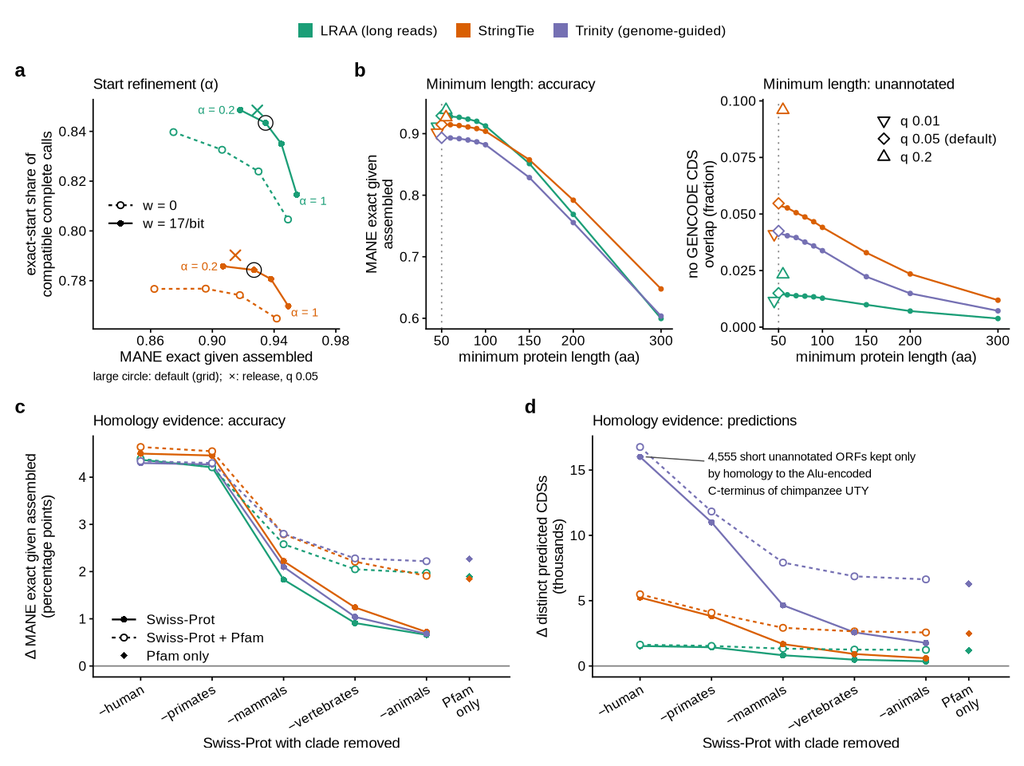

```r
fig7
```

Plotted values (each panel):

```r
kable(pa_dat %>% select(assembly, config, alpha, w, MANE_sens_exact_given_assembled,
                        pred_complete_start_precision) %>%
        bind_rows(pa_rel %>% transmute(assembly, config = "release default (cross)",
                                       MANE_sens_exact_given_assembled = mane,
                                       pred_complete_start_precision = share)),
      digits = 4, caption = "Panel a")
```

Panel a

| assembly | config | alpha | w | MANE_sens_exact_given_assembled | pred_complete_start_precision |
| --- | --- | --- | --- | --- | --- |
| lraa | a0.2_w0 | 0.2 | w = 0 | 0.8748 | 0.8397 |
| lraa | a0.2_w25 | 0.2 | w = 17/bit | 0.9180 | 0.8486 |
| lraa | a0.4_w0 | 0.4 | w = 0 | 0.9063 | 0.8326 |
| lraa | a0.4_w25 | 0.4 | w = 17/bit | 0.9345 | 0.8434 |
| lraa | a0.6_w0 | 0.6 | w = 0 | 0.9299 | 0.8239 |
| lraa | a0.6_w25 | 0.6 | w = 17/bit | 0.9447 | 0.8350 |
| lraa | a1.0_w0 | 1.0 | w = 0 | 0.9490 | 0.8046 |
| lraa | a1.0_w25 | 1.0 | w = 17/bit | 0.9547 | 0.8146 |
| stringtie | a0.2_w0 | 0.2 | w = 0 | 0.8624 | 0.7767 |
| stringtie | a0.2_w25 | 0.2 | w = 17/bit | 0.9069 | 0.7858 |
| stringtie | a0.4_w0 | 0.4 | w = 0 | 0.8957 | 0.7768 |
| stringtie | a0.4_w25 | 0.4 | w = 17/bit | 0.9270 | 0.7843 |
| stringtie | a0.6_w0 | 0.6 | w = 0 | 0.9178 | 0.7742 |
| stringtie | a0.6_w25 | 0.6 | w = 17/bit | 0.9379 | 0.7807 |
| stringtie | a1.0_w0 | 1.0 | w = 0 | 0.9417 | 0.7648 |
| stringtie | a1.0_w25 | 1.0 | w = 17/bit | 0.9492 | 0.7698 |
| lraa | release default (cross) | NA | NA | 0.9291 | 0.8484 |
| stringtie | release default (cross) | NA | NA | 0.9149 | 0.7902 |

**Panel b (lines and markers)**

```r
kable(sweep_v7 %>% select(assembly, min_aa, MANE_sens_exact_given_assembled,
                          pred_all_no_GENCODE_CDS_overlap_frac), digits = 4, caption = "Panel b, lines")
```

Panel b, lines

| assembly | min_aa | MANE_sens_exact_given_assembled | pred_all_no_GENCODE_CDS_overlap_frac |
| --- | --- | --- | --- |
| lraa | 50 | 0.9287 | 0.0146 |
| lraa | 60 | 0.9279 | 0.0143 |
| lraa | 70 | 0.9266 | 0.0139 |
| lraa | 80 | 0.9236 | 0.0137 |
| lraa | 90 | 0.9201 | 0.0134 |
| lraa | 100 | 0.9125 | 0.0128 |
| lraa | 150 | 0.8513 | 0.0099 |
| lraa | 200 | 0.7688 | 0.0071 |
| lraa | 300 | 0.5996 | 0.0038 |
| stringtie | 50 | 0.9148 | 0.0538 |
| stringtie | 60 | 0.9145 | 0.0527 |
| stringtie | 70 | 0.9132 | 0.0506 |
| stringtie | 80 | 0.9109 | 0.0487 |
| stringtie | 90 | 0.9082 | 0.0466 |
| stringtie | 100 | 0.9039 | 0.0441 |
| stringtie | 150 | 0.8575 | 0.0329 |
| stringtie | 200 | 0.7919 | 0.0235 |
| stringtie | 300 | 0.6477 | 0.0119 |
| trinity | 50 | 0.8932 | 0.0416 |
| trinity | 60 | 0.8930 | 0.0404 |
| trinity | 70 | 0.8919 | 0.0396 |
| trinity | 80 | 0.8897 | 0.0376 |
| trinity | 90 | 0.8867 | 0.0359 |
| trinity | 100 | 0.8820 | 0.0338 |
| trinity | 150 | 0.8286 | 0.0223 |
| trinity | 200 | 0.7555 | 0.0149 |
| trinity | 300 | 0.6036 | 0.0072 |

```r
kable(pb_pts %>% select(assembly, qs, MANE_exact_given_assembled, no_GENCODE_overlap), digits = 4,
      caption = "Panel b, markers (at 50 aa)")
```

Panel b, markers (at 50 aa)

| assembly | qs | MANE_exact_given_assembled | no_GENCODE_overlap |
| --- | --- | --- | --- |
| lraa | q 0.05 (default) | 0.9291 | 0.0150 |
| lraa | q 0.01 | 0.9115 | 0.0116 |
| lraa | q 0.2 | 0.9385 | 0.0233 |
| stringtie | q 0.05 (default) | 0.9149 | 0.0547 |
| stringtie | q 0.01 | 0.9018 | 0.0411 |
| stringtie | q 0.2 | 0.9266 | 0.0960 |
| trinity | q 0.05 (default) | 0.8933 | 0.0425 |

**Panels c and d**

```r
kable(hom_pl %>% select(assembly, config, db, x, d_mane_exact_pts, d_distinct_cds), digits = 3)
```

| assembly | config | db | x | d_mane_exact_pts | d_distinct_cds |
| --- | --- | --- | --- | --- | --- |
| lraa | blast_9606_nopfam | Swiss-Prot | −human | 4.37 | 1531 |
| lraa | blast_9443_nopfam | Swiss-Prot | −primates | 4.21 | 1434 |
| lraa | blast_40674_nopfam | Swiss-Prot | −mammals | 1.83 | 821 |
| lraa | blast_7742_nopfam | Swiss-Prot | −vertebrates | 0.91 | 484 |
| lraa | blast_33208_nopfam | Swiss-Prot | −animals | 0.66 | 360 |
| lraa | pfam | Pfam only | Pfam |  |  |
| only | 1.89 | 1190 |  |  |  |
| lraa | blast_9606_pfam | Swiss-Prot + Pfam | −human | 4.39 | 1628 |
| lraa | blast_9443_pfam | Swiss-Prot + Pfam | −primates | 4.21 | 1537 |
| lraa | blast_40674_pfam | Swiss-Prot + Pfam | −mammals | 2.58 | 1330 |
| lraa | blast_7742_pfam | Swiss-Prot + Pfam | −vertebrates | 2.05 | 1257 |
| lraa | blast_33208_pfam | Swiss-Prot + Pfam | −animals | 1.97 | 1233 |
| stringtie | blast_9606_nopfam | Swiss-Prot | −human | 4.50 | 5242 |
| stringtie | blast_9443_nopfam | Swiss-Prot | −primates | 4.46 | 3814 |
| stringtie | blast_40674_nopfam | Swiss-Prot | −mammals | 2.22 | 1674 |
| stringtie | blast_7742_nopfam | Swiss-Prot | −vertebrates | 1.24 | 917 |
| stringtie | blast_33208_nopfam | Swiss-Prot | −animals | 0.72 | 592 |
| stringtie | pfam | Pfam only | Pfam |  |  |
| only | 1.85 | 2482 |  |  |  |
| stringtie | blast_9606_pfam | Swiss-Prot + Pfam | −human | 4.64 | 5489 |
| stringtie | blast_9443_pfam | Swiss-Prot + Pfam | −primates | 4.55 | 4082 |
| stringtie | blast_40674_pfam | Swiss-Prot + Pfam | −mammals | 2.79 | 2924 |
| stringtie | blast_7742_pfam | Swiss-Prot + Pfam | −vertebrates | 2.21 | 2649 |
| stringtie | blast_33208_pfam | Swiss-Prot + Pfam | −animals | 1.91 | 2568 |
| trinity | blast_9606_nopfam | Swiss-Prot | −human | 4.30 | 16009 |
| trinity | blast_9443_nopfam | Swiss-Prot | −primates | 4.27 | 11002 |
| trinity | blast_40674_nopfam | Swiss-Prot | −mammals | 2.10 | 4650 |
| trinity | blast_7742_nopfam | Swiss-Prot | −vertebrates | 1.04 | 2573 |
| trinity | blast_33208_nopfam | Swiss-Prot | −animals | 0.68 | 1769 |
| trinity | pfam | Pfam only | Pfam |  |  |
| only | 2.27 | 6288 |  |  |  |
| trinity | blast_9606_pfam | Swiss-Prot + Pfam | −human | 4.34 | 16764 |
| trinity | blast_9443_pfam | Swiss-Prot + Pfam | −primates | 4.30 | 11827 |
| trinity | blast_40674_pfam | Swiss-Prot + Pfam | −mammals | 2.80 | 7917 |
| trinity | blast_7742_pfam | Swiss-Prot + Pfam | −vertebrates | 2.28 | 6863 |
| trinity | blast_33208_pfam | Swiss-Prot + Pfam | −animals | 2.22 | 6632 |

Caption notes for the text: the caption’s panel b markers and the `\todo` in it should be replaced by the q settings (q 0.01, 0.05, 0.2; release runs); the lines are now the release predictions. Panel a now has the release default as a cross.

## Checks against the manuscript

Values computed here against the values in results_gm12878_parameters.tex (line numbers in the labels) and the Fig. 7 caption. Where the text quotes development runs and the release value differs, the row shows `ok = FALSE`; these are the numbers the text should update (see the `\todo` at line 29).

```r
check_report()
```

| claim | computed | manuscript | ok |
| --- | --- | --- | --- |
| L13 StringTie MANE exact given assembled, no refinement (%) | 61.03 | 61 | TRUE |
| L13 StringTie MANE exact given assembled, default (%) | 92.7 | 92.7 | TRUE |
| L13 LRAA MANE exact given assembled, no refinement (%) | 59.06 | 59.1 | TRUE |
| L13 LRAA MANE exact given assembled, default (%) | 93.45 | 93.5 | TRUE |
| L14 StringTie exact complete calls, no refinement | 9309 | 9309 | TRUE |
| L14 StringTie exact complete calls, default | 13805 | 13805 | TRUE |
| L14 LRAA exact complete calls, no refinement | 7562 | 7562 | TRUE |
| L14 LRAA exact complete calls, default | 12018 | 12018 | TRUE |
| L15 StringTie 5’-partial, no refinement | 10544 | 10544 | TRUE |
| L15 StringTie 5’-partial, default | 3030 | 3030 | TRUE |
| L15 LRAA 5’-partial, no refinement | 10693 | 10693 | TRUE |
| L15 LRAA 5’-partial, default | 2631 | 2631 | TRUE |
| L16 StringTie exact-start share, no refinement (%) | 73.27 | 73.3 | TRUE |
| L16 StringTie exact-start share, default (%) | 78.43 | 78.4 | TRUE |
| L17 LRAA exact-start share, no refinement (%) | 81.67 | 81.7 | TRUE |
| L17 LRAA exact-start share, default (%) | 84.34 | 84.3 | TRUE |
| L17 StringTie wrong-start complete, no refinement | 3396 | 3396 | TRUE |
| L17 StringTie wrong-start complete, default | 3796 | 3796 | TRUE |
| L17 LRAA wrong-start complete, no refinement | 1697 | 1697 | TRUE |
| L18 LRAA wrong-start complete, default | 2231 | 2231 | TRUE |
| L18 Kozak term, StringTie MANE exact (points) | 3.13 | 3.1 | TRUE |
| L18 Kozak term, LRAA MANE exact (points) | 2.82 | 2.8 | TRUE |
| L18 Kozak term, StringTie exact-start share (points) | 0.75 | 0.8 | TRUE |
| L19 Kozak term, LRAA exact-start share (points) | 1.08 | 1.1 | TRUE |
| L20 StringTie MANE exact given assembled, alpha 1.0 (%) | 94.92 | 94.9 | TRUE |
| L20 LRAA MANE exact given assembled, alpha 1.0 (%) | 95.47 | 95.5 | TRUE |
| L21 StringTie exact-start share, alpha 1.0 (%) | 76.98 | 77 | TRUE |
| L21 LRAA exact-start share, alpha 1.0 (%) | 81.46 | 81.5 | TRUE |
| caption 7a LRAA no refinement MANE | 0.5906 | 0.59 | TRUE |
| caption 7a LRAA no refinement exact-start share | 0.8167 | 0.82 | TRUE |

[output cut: 80 more lines]